# Session 4: Homework 2

MAM Group 5

2021-09-12

# 1 Climate change and temperature anomalies

We want to analyse the climate change in the period between 1951-1980

First, we load the data from *Combined Land-Surface Air and Sea-Surface Water Temperature Anomalies* in the Northern Hemisphere at [NASA’s Goddard Institute for Space Studies](https://data.giss.nasa.gov/gistemp). The [tabular data of temperature anomalies can be found here](https://data.giss.nasa.gov/gistemp/tabledata_v4/NH.Ts+dSST.txt)

```r
weather <-
  read_csv("https://data.giss.nasa.gov/gistemp/tabledata_v4/NH.Ts+dSST.csv",
           skip = 1,
           na = "***")
```

We modified the data by adding `skip` and `na`, and we select the year and the twelve month variables from the dataset while deleting the rest as they are non-relevant.

```r
tidyweather <- weather %>%  select(1:13) %>% pivot_longer(cols=2:13, names_to = "Month", values_to="delta")

tidyweather
```

```
## # A tibble: 1,704 x 3
##     Year Month delta
##    <dbl> <chr> <dbl>
##  1  1880 Jan   -0.35
##  2  1880 Feb   -0.5
##  3  1880 Mar   -0.23
##  4  1880 Apr   -0.29
##  5  1880 May   -0.05
##  6  1880 Jun   -0.15
##  7  1880 Jul   -0.18
##  8  1880 Aug   -0.25
##  9  1880 Sep   -0.23
## 10  1880 Oct   -0.32
## # ... with 1,694 more rows
```

Now we inspect the dataframe, it has three columns indicating the Year, Month and the delta value of climate change which shows how much the temperature varys from the base year.

## 1.1 Plotting Information

We plot the data using a time-series scatter plot, and have added a trendline. We first created a new variable called `date` in order to ensure that the `delta` values are plot chronologically.

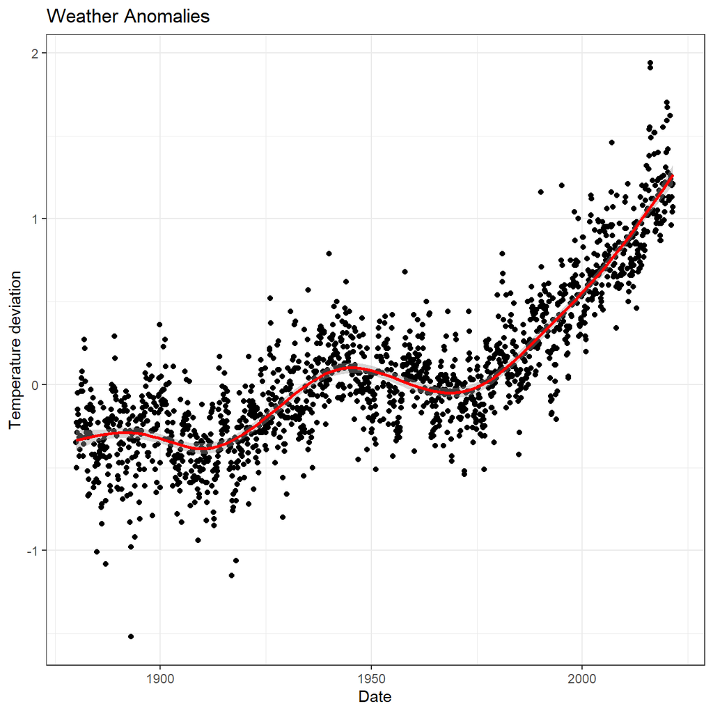

```r
# convert the date time datatype
tidyweather <- tidyweather %>%
  mutate(date = ymd(paste(as.character(Year), Month, "1")),
         month = month(date, label=TRUE),
         year = year(date))

# plotting the scatter plot of the data
ggplot(tidyweather, aes(x=date, y = delta))+
  geom_point()+
  geom_smooth(color="red") +
  theme_bw() +
  labs (
    title = "Weather Anomalies",
    x = "Date",
    y = "Temperature deviation"
  )+
  NULL
```

Now we will visualize the data in a per-month basis, to see if the effect of increasing temperature is more pronounced in some months than others.

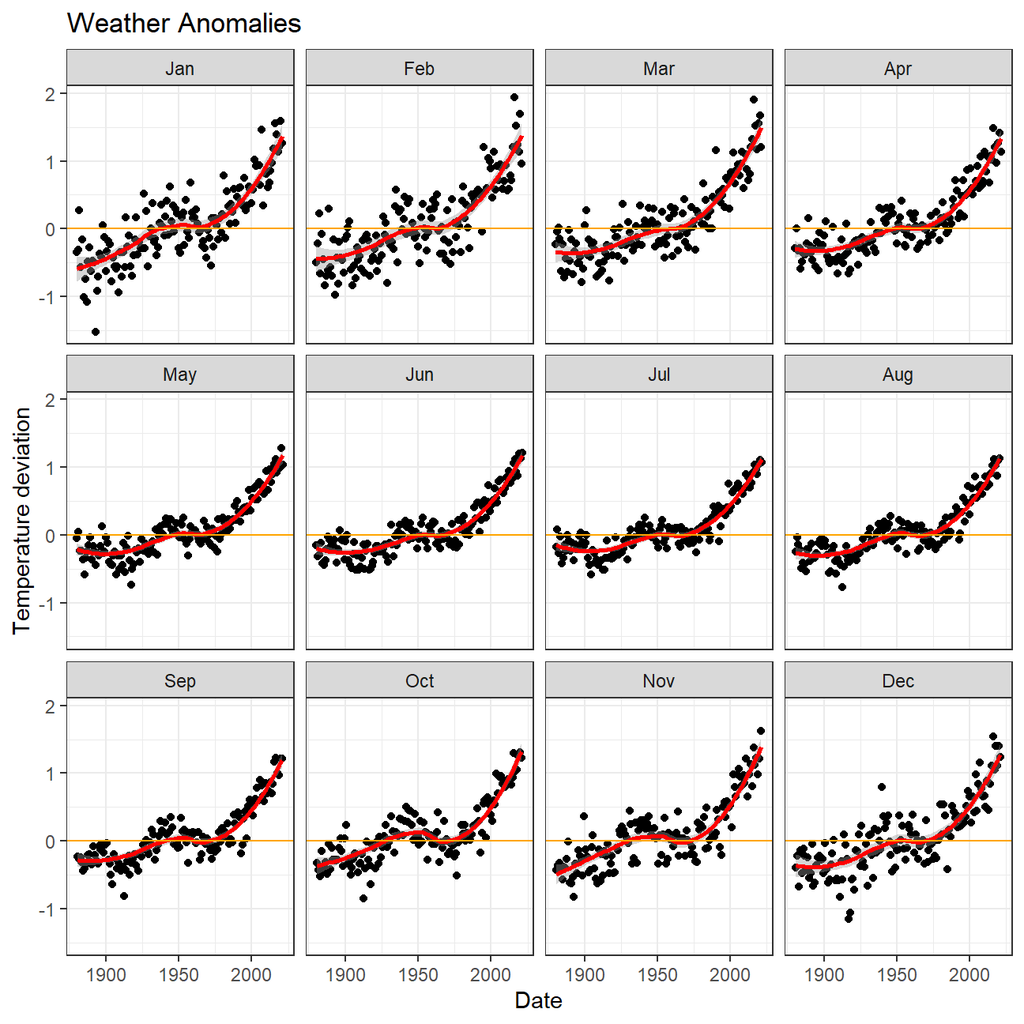

```r
#plotting the by-month scatter plot of data
ggplot(tidyweather, aes(x=date, y = delta))+
  geom_point()+
  geom_smooth(color="red") +
  geom_hline(yintercept = 0, color="orange")+
  theme_bw() +
  labs (
    title = "Weather Anomalies",
    x = "Date",
    y = "Temperature deviation"
  )+
  facet_wrap(~month)+
  NULL
```

- From the above chart we can see the temperature deviation is smaller from May to August as the data points are less spread out on the y axis.

To study the historical data, we found it useful to group data into different time periods. Therefore, we created a new data frame called `comparison` that groups data in five time periods: 1881-1920, 1921-1950, 1951-1980, 1981-2010 and 2011-present.

```r
comparison <- tidyweather %>%
  filter(Year>= 1881) %>%     #remove years prior to 1881
  #create new variable 'interval', and assign values based on criteria below:
  mutate(interval = case_when(
    Year %in% c(1881:1920) ~ "1881-1920",
    Year %in% c(1921:1950) ~ "1921-1950",
    Year %in% c(1951:1980) ~ "1951-1980",
    Year %in% c(1981:2010) ~ "1981-2010",
    TRUE ~ "2011-present"
  ))
```

By clicking on it in the `Environment` pane, we inspected the dataframe and it has 7 columns: Year, Month, delta, date, month, year, interval which we just created.

Now that we have the `interval` variable, we can create a density plot to study the distribution of monthly deviations (`delta`), grouped by the different time periods we are interested in.

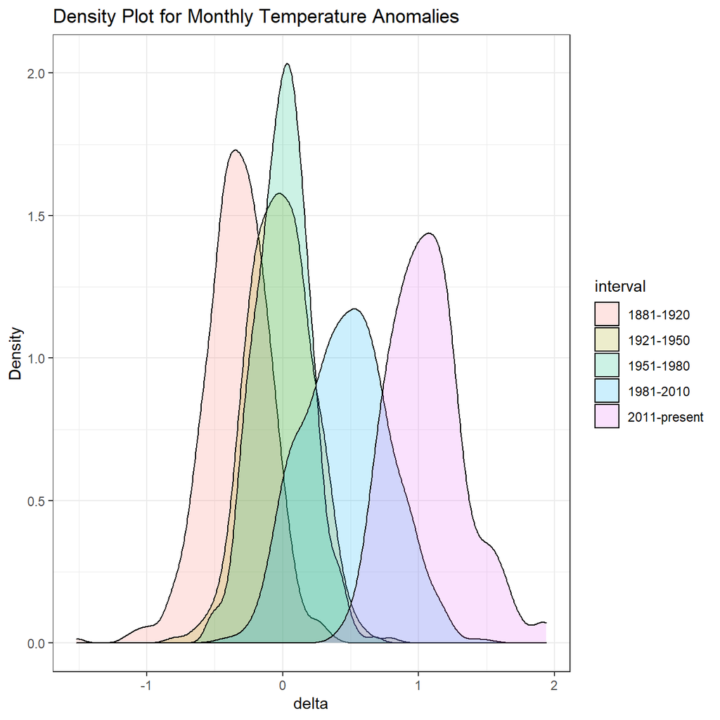

```r
# Set `fill` to `interval` to group and colour the data by different time periods.
ggplot(comparison, aes(x=delta, fill=interval))+
  geom_density(alpha=0.2) +   #density plot with tranparency set to 20%
  theme_bw() +                #theme
  labs (
    title = "Density Plot for Monthly Temperature Anomalies",
    y     = "Density"         #changing y-axis label to sentence case
  )
```

We are also interested in average annual anomalies, therefore we further modified the data to produce a scatter plot as below:

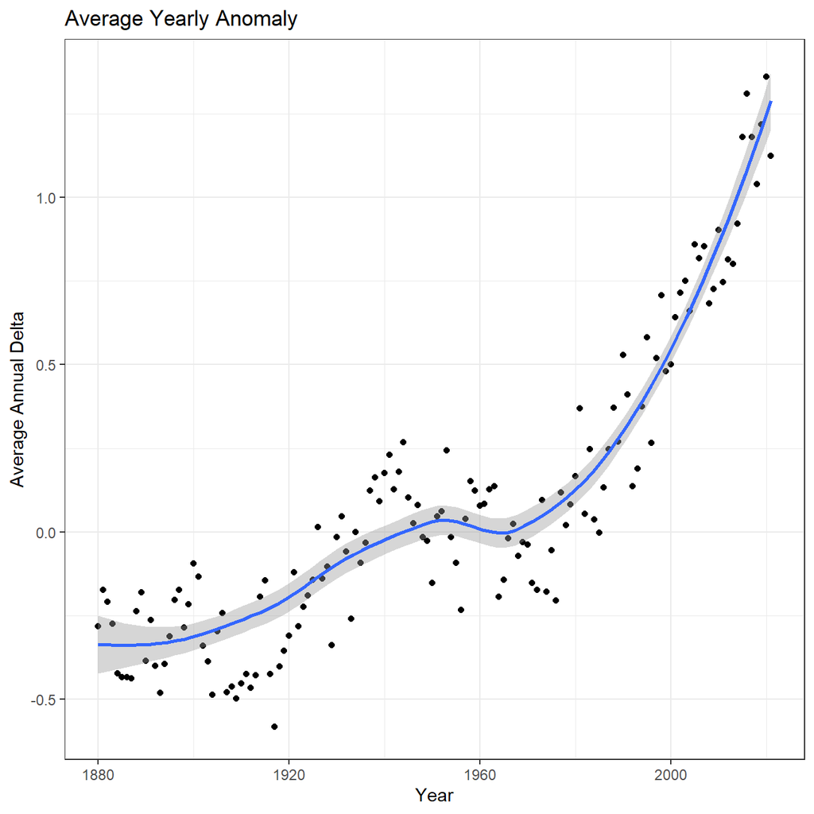

```r
#creating yearly averages
average_annual_anomaly <- tidyweather %>%
  group_by(Year) %>%   #grouping data by Year

  # creating summaries for mean delta
  # use `na.rm=TRUE` to eliminate NA (not available) values
  summarise(annual_average_delta = mean(delta, na.rm=TRUE))

#plotting the data:
ggplot(average_annual_anomaly, aes(x=Year, y= annual_average_delta))+
  geom_point()+

  #Fit the best fit line, using LOESS method
  geom_smooth() +

  #change to theme_bw() to have white background + black frame around plot
  theme_bw() +
  labs (
    title = "Average Yearly Anomaly",
    y     = "Average Annual Delta"
  )
```

- As we can see from the plot, it corresponded to our earlier conclusion that the temperature is increasing at a larger rate starting significantly since 1960s.

## 1.2 Confidence Interval for `delta`

[NASA points out on their website](https://earthobservatory.nasa.gov/world-of-change/decadaltemp.php) that

> A one-degree global change is significant because it takes a vast amount of heat to warm all the oceans, atmosphere, and land by that much. In the past, a one- to two-degree drop was all it took to plunge the Earth into the Little Ice Age.

We want to construct a confidence interval for the average annual delta since 2011, both using a formula and using a bootstrap simulation with the `infer` package. Recall that the dataframe `comparison` has already grouped temperature anomalies according to time intervals; we are only interested in what is happening between 2011-present.

```r
formula_ci <- comparison %>% filter(interval =="2011-present") %>%
  summarise(annual_average_delta = mean(delta, na.rm=TRUE),
            sd_delta = sd(delta, na.rm=TRUE),
            count = n(),
            se_delta = sd_delta/sqrt(count),
            t_critical = qt(0.975, count-1),
            margin_of_error = t_critical * se_delta,
            delta_low = annual_average_delta - margin_of_error,
            delta_high = annual_average_delta + margin_of_error)

  # choose the interval 2011-present
  # what dplyr verb will you use?

  # calculate summary statistics for temperature deviation (delta)
  # calculate mean, SD, count, SE, lower/upper 95% CI
  # what dplyr verb will you use?

  # summarise(ann_aver_delta = mean(delta,na.rm=T),
  #           sd_delta = sd(delta,na.rm=T),
  #           count=n(),
  #           t_critical = qt(0.975,count-1),
  #           margin_of_error = t_critical*sd_delta/sqrt(count),
  #           delta_low = ann_aver_delta-margin_of_error,
  #           delta_high = ann_aver_delta+margin_of_error)
#print out formula_CI
formula_ci
```

```
## # A tibble: 1 x 8
##   annual_average_delta sd_delta count se_delta t_critical margin_of_error delta_low
##                  <dbl>    <dbl> <int>    <dbl>      <dbl>           <dbl>     <dbl>
## 1                 1.06    0.276   132   0.0240       1.98          0.0475      1.01
## # ... with 1 more variable: delta_high <dbl>
```

```r
# use the infer package to construct a 95% CI for delta
set.seed(1234)

boot_delta<- comparison %>%
  filter(interval =="2011-present") %>%
  specify(response = delta) %>%
  generate(reps = 1000, type = "bootstrap") %>%
  calculate(stat = "mean") %>%
  get_confidence_interval(level = 0.95, type = "percentile")

boot_delta
```

```
## # A tibble: 1 x 2
##   lower_ci upper_ci
##      <dbl>    <dbl>
## 1     1.01     1.11
```

First we filtered out the years to include only 2011-present. Then we calculated summary statistics including the mean,sd,se and from this we calculated the confidence interval.

- Using both the bootstrap method and the formula method we got a 95% confidence interval for delta as (1.01,1.11).
- This means that we are 95% confident that the true mean for 2011-present for delta lies within the range of (1.01,1.11). We can confirm that there is a net increase in temperature since the base year.

# 2 General Social Survey (GSS)

The [General Social Survey (GSS)](http://www.gss.norc.org/) gathers data on American society in order to monitor and explain trends in attitudes, behaviours, and attributes. Many trends have been tracked for decades, so one can see the evolution of attitudes, etc in American Society.

We analyzed data from the **2016 GSS sample data**, using it to estimate values of *population parameters* of interest about US adults. The GSS sample data file has 2867 observations of 935 variables, but we are only interested in very few of these variables and therefore we filtered the data into a smaller file.

```r
gss <- read_csv(here::here("data", "smallgss2016.csv"),
                na = c("", "Don't know",
                       "No answer", "Not applicable"))
```

We noticed that many responses should not be taken into consideration, like “No Answer”, “Don’t Know”, “Not applicable”, “Refused to Answer”.

We will be creating 95% confidence intervals for population parameters. The variables we have are the following: hours and minutes spent on email weekly. The responses to these questions are recorded in the `emailhr` and `emailmin` variables. For example, if the response is 2.50 hours, this would be recorded as emailhr = 2 and emailmin = 30. `snapchat`, `instagrm`, `twitter`: whether respondents used these social media in 2016 `sex`: Female - Male `degree`: highest education level attained

## 2.1 Instagram and Snapchat, by sex

We would like to estimate the *population* proportion of Snapchat or Instagram users in 2016, by following the below steps:

```r
#Step 1
gss<-gss %>% mutate(snap_insta = case_when(
  (snapchat =="Yes" | instagrm == "Yes") ~ "Yes",
  (snapchat =="No" & instagrm == "No") ~ "No",
  T ~ "NA"))

#Step 2
gss %>%
  filter(!snap_insta == "NA") %>%
  count(snap_insta, sort=TRUE) %>%
  mutate(prop = n/sum(n))
```

```
## # A tibble: 2 x 3
##   snap_insta     n  prop
##   <chr>      <int> <dbl>
## 1 No           858 0.625
## 2 Yes          514 0.375
```

```r
# se for proportion = sqrt (P*(1-P)/n)

#Step 3
se_prop = sqrt(
  0.625 * 0.375 / (514+858)
)

conf_low <-  0.375 - 1.96 * se_prop
conf_high <- 0.375 + 1.96 * se_prop

conf_high
```

```
## [1] 0.401
```

```r
conf_low
```

```
## [1] 0.349
```

- We are 95% confident that the true proportion of instagram or snap users falls between 0.349 and 0.401.

## 2.2 Twitter, by education level

Next, we estimated the *population* proportion of Twitter users by education level in 2016 in the following stages

1.We calculate the proportion of `bachelor_graduate` who do (Yes) and who don’t (No) use twitter. 2. Using the CI formula for proportions, we constructed two 95% CIs for `bachelor_graduate` vs whether they use (Yes) and don’t (No) use twitter. 3. We assessed whether or not these confidence intervals overlapped?

```r
#Turn `degree` from a character variable into a factor variable
#Create a  new variable, `bachelor_graduate` to indicate if the respondent is bachelor or graduate
gss <- gss %>%
  mutate(degree = factor(degree, levels=c("Lt high school","High school", "Junior college", "Bachelor", "Graduate")),
                       bachelor_graduate = case_when(
  (degree =="Bachelor" | degree == "Graduate") ~ "Yes",
  (degree != "Bachelor" & degree != "Graduate") ~ "No",
  T ~ "NA"))

#Calculate the proportion of `bachelor_graduate` who do (Yes) and who don't (No) use twitter
gss %>% filter(bachelor_graduate == "Yes") %>%
  filter(twitter != "NA") %>%
  count(twitter, sort=TRUE) %>%
  mutate(prop = n/sum(n))
```

```
## # A tibble: 2 x 3
##   twitter     n  prop
##   <chr>   <int> <dbl>
## 1 No        375 0.767
## 2 Yes       114 0.233
```

```r
#Using the CI formula for proportions
se_prop_usetwitter = sqrt(
  0.767 * 0.233 / (114+375)
)

se_prop_notwitter = sqrt(
  0.767 * 0.233 / (375+144)
)


conf_low_usetwitter <-  0.233 - qt(0.975, 113) * se_prop_usetwitter
conf_high_usetwitter <- 0.233 + qt(0.975, 113) * se_prop_usetwitter

conf_low_notwitter <-  0.767 - qt(0.975, 374) * se_prop_notwitter
conf_high_notwitter <- 0.767 + qt(0.975, 374) * se_prop_notwitter


conf_low_notwitter
```

```
## [1] 0.731
```

```r
conf_high_notwitter
```

```
## [1] 0.803
```

```r
conf_low_usetwitter
```

```
## [1] 0.195
```

```r
conf_high_usetwitter
```

```
## [1] 0.271
```

- The 95% confidence interval for the proportion of bachelors and graduates that do not use twitter is 0.731 to 0.803.
- The 95% confidence interval for the proportion of bachelors and graduates that do use twitter is 0.195 to 0.271.

## 2.3 Email usage

Next we estimated the *population* parameter on time spent on email weekly.

- The mean of the number of minutes spent on email weekly is 417 minutes and the median is 120 minutes. The median is a better measure of the typical amount of time Americans spent on email weekly as the mean is substantially increased due to the outliers of extremely high email usage. Multiple individuals claimed to spend more than 4000 minutes on email weekly which skews the mean higher. The median is a more accurate representation of typical usage as it isn’t affected by the outliers.
- The 95% CI for the mean weekly email time is 6 hours and 25 minutes to 7 hours and 33 minutes. There does not seem to be an odd result. The mean of the dataset is 6hrs and 57 minutes which falls into this CI.
- One would expect a 99% confidence interval to be wider than the 95% CI. This is because to be more certain about the values of the mean weekly email time it is necessary to increase the range and hence have a wider interval. Also mathematically the t-critical value is larger and hence the CI is wider.

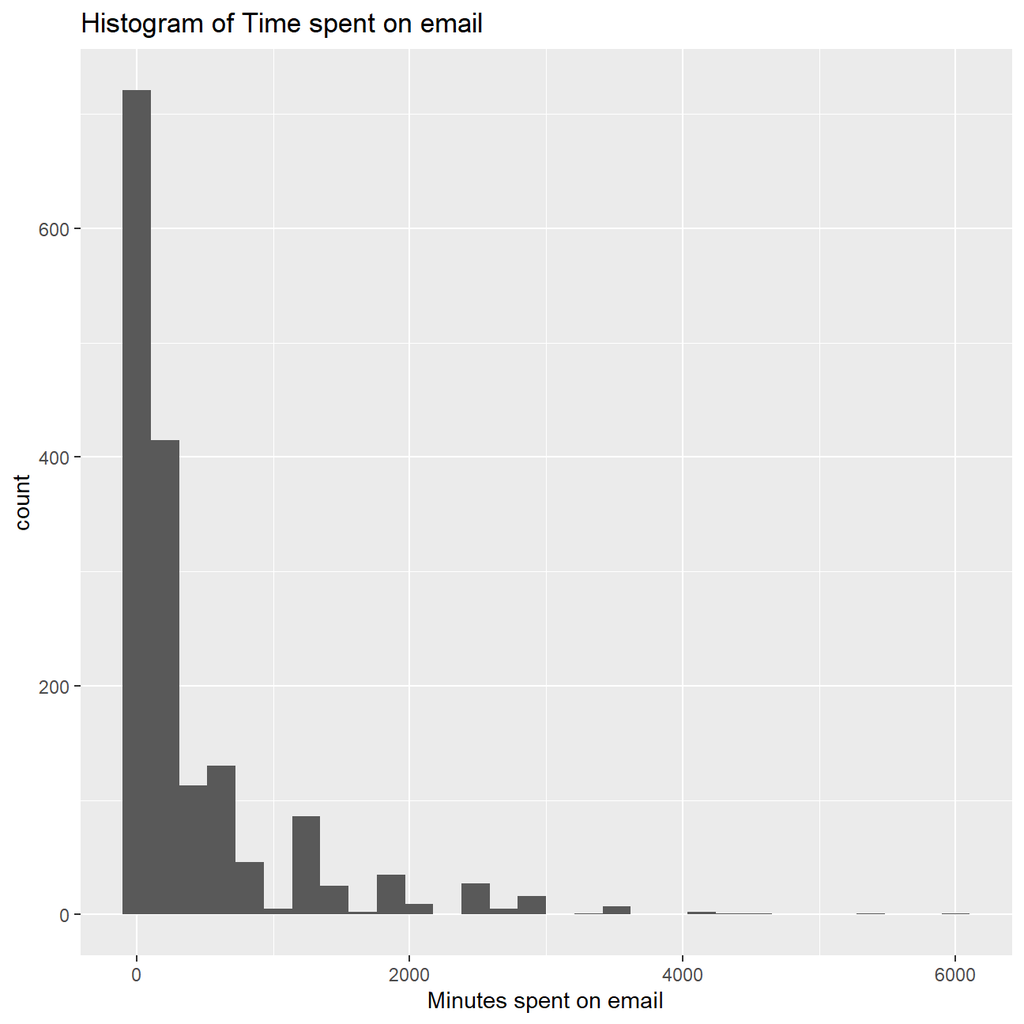

```r
set.seed(1234)
#Converts email hr and email min into one variable called email
gss <- gss %>%
  mutate(email = as.numeric(emailhr) * 60 + as.numeric(emailmin))
#Creates histogram showing the distribution of email
gss %>%
  ggplot(aes(x=email)) +
  geom_histogram() + labs(title = "Histogram of Time spent on email",
                          x= "Minutes spent on email")
```

```r
gss %>% summarise(meanEmail = mean(email, na.rm=TRUE),
                  medianEmail = median(email, na.rm=TRUE))
```

```
## # A tibble: 1 x 2
##   meanEmail medianEmail
##       <dbl>       <dbl>
## 1      417.         120
```

```r
#Bootstrap creating a 95% confidence interval for the mean weekly email usage.
boot_email <- gss %>%
  specify(response = email) %>%
  generate(reps = 1000, type = "bootstrap") %>%
  calculate(stat = "mean") %>%
  get_confidence_interval(level = 0.95, type = "percentile")

boot_email
```

```
## # A tibble: 1 x 2
##   lower_ci upper_ci
##      <dbl>    <dbl>
## 1     385.     453.
```

```r
hours = boot_email%/%60 #Calculates the hours using integer division (61 minutes will give 1 hour)
minutes = round(boot_email%%60) # Calculates hours using modulus division (getting remainder) (61 min will give 1 minute)

paste(hours, "hours", minutes, "minutes") # function to paste the values for the confidence interval: "6 hours 25 minutes" "7 hours 33 minutes"
```

```
## [1] "6 hours 25 minutes" "7 hours 33 minutes"
```

```r
# wider
#Bootstrap creating a 99% confidence interval for the mean weekly email usage.
# boot_email2 <- gss %>%
#   specify(response = email) %>%
#   generate(reps = 1000, type = "bootstrap") %>%
#   calculate(stat = "mean") %>%
#   get_confidence_interval(level = 0.99, type = "percentile")
# boot_email2
```

# 3 Biden’s Approval Margins

We will now start our analysis of Biden’s approval ratings. Fivethirtyeight.com has detailed data on [all polls that track the president’s approval](https://projects.fivethirtyeight.com/biden-approval-ratings)

```r
# Import approval polls data directly off fivethirtyeight website
approval_polllist <- read_csv('https://projects.fivethirtyeight.com/biden-approval-data/approval_polllist.csv')

glimpse(approval_polllist)
```

```
## Rows: 1,597
## Columns: 22
## $ president           <chr> "Joseph R. Biden Jr.", "Joseph R. Biden Jr.", "Jos…
## $ subgroup            <chr> "All polls", "All polls", "All polls", "All polls"…
## $ modeldate           <chr> "9/10/2021", "9/10/2021", "9/10/2021", "9/10/2021"…
## $ startdate           <chr> "1/24/2021", "1/24/2021", "1/25/2021", "1/25/2021"…
## $ enddate             <chr> "1/26/2021", "1/27/2021", "1/27/2021", "1/26/2021"…
## $ pollster            <chr> "Rasmussen Reports/Pulse Opinion Research", "Maris…
## $ grade               <chr> "B", "A", "B", "B", "B", "B", "B", "B+", "B", "B",…
## $ samplesize          <dbl> 1500, 1313, 1500, 2200, 15000, 9212, 1500, 906, 15…
## $ population          <chr> "lv", "a", "lv", "a", "a", "a", "lv", "a", "a", "a…
## $ weight              <dbl> 0.3225, 2.1893, 0.3025, 0.1205, 0.2739, 0.1520, 0.…
## $ influence           <dbl> 0, 0, 0, 0, 0, 0, 0, 0, 0, 0, 0, 0, 0, 0, 0, 0, 0,…
## $ approve             <dbl> 48.0, 49.0, 49.0, 58.0, 54.0, 55.0, 50.0, 57.0, 54…
## $ disapprove          <dbl> 48.0, 35.0, 48.0, 32.0, 31.0, 31.5, 45.0, 37.0, 32…
## $ adjusted_approve    <dbl> 50.4, 50.0, 51.4, 56.5, 52.5, 53.5, 52.4, 56.3, 52…
## $ adjusted_disapprove <dbl> 41.9, 34.6, 41.9, 35.4, 34.4, 34.9, 38.9, 36.4, 35…
## $ multiversions       <chr> NA, NA, NA, NA, NA, "*", NA, NA, NA, NA, NA, NA, N…
## $ tracking            <lgl> TRUE, NA, TRUE, NA, TRUE, TRUE, TRUE, NA, TRUE, NA…
## $ url                 <chr> "https://www.rasmussenreports.com/public_content/p…
## $ poll_id             <dbl> 74261, 74320, 74268, 74346, 74277, 74292, 74290, 7…
## $ question_id         <dbl> 139433, 139558, 139483, 139653, 139497, 139518, 13…
## $ createddate         <chr> "1/27/2021", "2/1/2021", "1/28/2021", "2/5/2021", …
## $ timestamp           <chr> "18:35:08 10 Sep 2021", "18:35:08 10 Sep 2021", "1…
```

```r
# Use `lubridate` to fix dates, as they are given as characters.

approval_polllist <- approval_polllist %>%
  mutate(modeldate = mdy(modeldate),
         startdate = mdy(startdate),
         enddate = mdy(enddate),
         createddate = mdy(createddate))
```

## 3.1 Creating a Plot

Now we will calculate the average net approval rate (approve- disapprove) for each week since Biden got into office. We will plot Biden’s net approval, along with its 95% confidence interval. For the date, we will use `enddate`, i.e., the date the poll ended.

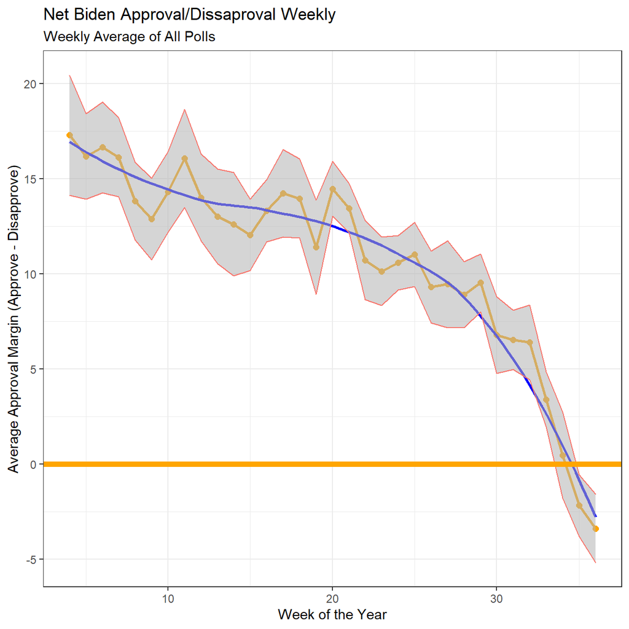

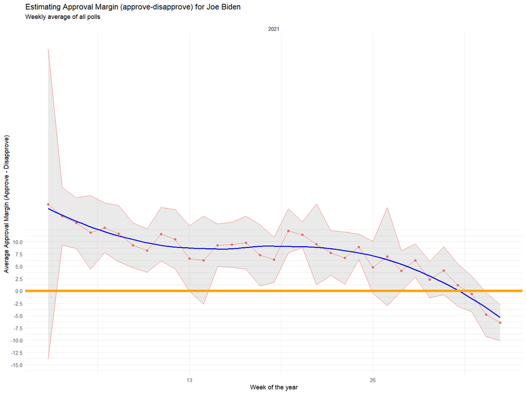

# 4 Gapminder revisited

Now we look at multiple data frames listed below-

1. Life expectancy at birth (life_expectancy_years.csv)
2. GDP per capita in constant 2010 US$ (https://data.worldbank.org/indicator/NY.GDP.PCAP.KD) 3.Female fertility: The number of babies per woman (https://data.worldbank.org/indicator/SP.DYN.TFRT.IN)
3. Primary school enrollment as % of children attending primary school (https://data.worldbank.org/indicator/SE.PRM.NENR)
4. Mortality rate, for under 5, per 1000 live births (https://data.worldbank.org/indicator/SH.DYN.MORT)
5. HIV prevalence (adults_with_hiv_percent_age_15_49.csv): The estimated number of people living with HIV per 100 population of age group 15-49.

```r
# load gapminder HIV data
hiv <- read_csv(here::here("data","adults_with_hiv_percent_age_15_49.csv"))
life_expectancy <- read_csv(here::here("data","life_expectancy_years.csv"))

# get World bank data using wbstats
indicators <- c("SP.DYN.TFRT.IN","SE.PRM.NENR", "SH.DYN.MORT", "NY.GDP.PCAP.KD")


library(wbstats)

worldbank_data <- wb_data(country="countries_only", #countries only- no aggregates like Latin America, Europe, etc.
                          indicator = indicators,
                          start_date = 1960,
                          end_date = 2016)

# get a dataframe of information regarding countries, indicators, sources, regions, indicator topics, lending types, income levels,  from the World Bank API
countries <-  wbstats::wb_cachelist$countries
```

```r
hiv_long <- hiv %>%
  pivot_longer(cols = 2:34, #columns 2 to 34
               names_to = "Year",
               values_to = "HIV_Value")

skim(hiv_long)
```

Data summary

| Name | hiv_long |
| --- | --- |
| Number of rows | 5082 |
| Number of columns | 3 |
| _______________________ |  |
| Column type frequency: |  |
| character | 2 |
| numeric | 1 |
| ________________________ |  |
| Group variables | None |

**Variable type: character**

| skim_variable | n_missing | complete_rate | min | max | empty | n_unique | whitespace |
| --- | --- | --- | --- | --- | --- | --- | --- |
| country | 0 | 1 | 3 | 24 | 0 | 154 | 0 |
| Year | 0 | 1 | 4 | 4 | 0 | 33 | 0 |

**Variable type: numeric**

| skim_variable | n_missing | complete_rate | mean | sd | p0 | p25 | p50 | p75 | p100 | hist |
| --- | --- | --- | --- | --- | --- | --- | --- | --- | --- | --- |
| HIV_Value | 1781 | 0.65 | 1.74 | 4.09 | 0.01 | 0.1 | 0.3 | 1.2 | 26.5 | ▇▁▁▁▁ |

```r
hiv_long
```

```
## # A tibble: 5,082 x 3
##    country     Year  HIV_Value
##    <chr>       <chr>     <dbl>
##  1 Afghanistan 1979         NA
##  2 Afghanistan 1980         NA
##  3 Afghanistan 1981         NA
##  4 Afghanistan 1982         NA
##  5 Afghanistan 1983         NA
##  6 Afghanistan 1984         NA
##  7 Afghanistan 1985         NA
##  8 Afghanistan 1986         NA
##  9 Afghanistan 1987         NA
## 10 Afghanistan 1988         NA
## # ... with 5,072 more rows
```

```r
life_expectancy_long <- life_expectancy %>%
                          pivot_longer(cols = 2:302, #columns 2 to 302
                       names_to = "Year",
                    values_to = "Life_Expectancy_Value")

skim(life_expectancy_long)
```

Data summary

| Name | life_expectancy_long |
| --- | --- |
| Number of rows | 56287 |
| Number of columns | 3 |
| _______________________ |  |
| Column type frequency: |  |
| character | 2 |
| numeric | 1 |
| ________________________ |  |
| Group variables | None |

**Variable type: character**

| skim_variable | n_missing | complete_rate | min | max | empty | n_unique | whitespace |
| --- | --- | --- | --- | --- | --- | --- | --- |
| country | 0 | 1 | 3 | 30 | 0 | 187 | 0 |
| Year | 0 | 1 | 4 | 4 | 0 | 301 | 0 |

**Variable type: numeric**

| skim_variable | n_missing | complete_rate | mean | sd | p0 | p25 | p50 | p75 | p100 | hist |
| --- | --- | --- | --- | --- | --- | --- | --- | --- | --- | --- |
| Life_Expectancy_Value | 759 | 0.99 | 53 | 21.7 | 1.01 | 32.3 | 48.7 | 74.2 | 94.8 | ▁▇▂▅▅ |

```r
life_expectancy_long
```

```
## # A tibble: 56,287 x 3
##    country     Year  Life_Expectancy_Value
##    <chr>       <chr>                 <dbl>
##  1 Afghanistan 1800                   28.2
##  2 Afghanistan 1801                   28.2
##  3 Afghanistan 1802                   28.2
##  4 Afghanistan 1803                   28.2
##  5 Afghanistan 1804                   28.2
##  6 Afghanistan 1805                   28.2
##  7 Afghanistan 1806                   28.1
##  8 Afghanistan 1807                   28.1
##  9 Afghanistan 1808                   28.1
## 10 Afghanistan 1809                   28.1
## # ... with 56,277 more rows
```

```r
#Merged HIV & Life_Expectancy data by matching Year and Country
hiv_life_expectancy <- hiv_long %>% inner_join(  life_expectancy_long , by = c ( "country","Year" ))

#Renaming date column to Year on World Bank Data

worldbank_data <- rename(worldbank_data ,Year=date)


worldbank_data <- worldbank_data %>%
  mutate(Year = as.character(Year))


#skim(hiv_life_expectancy)
#skim(worldbank_data)

#Merging Life Exp & HIV data with World bank data by Country & Year
hiv_life_expectancy_worldbank_data <- hiv_life_expectancy %>% inner_join( worldbank_data , by = c ( "country","Year" )  )
```

1. We checked the relationship between HIV prevalence and life expectancy by generating a scatterplot with a smoothing line to report your results.

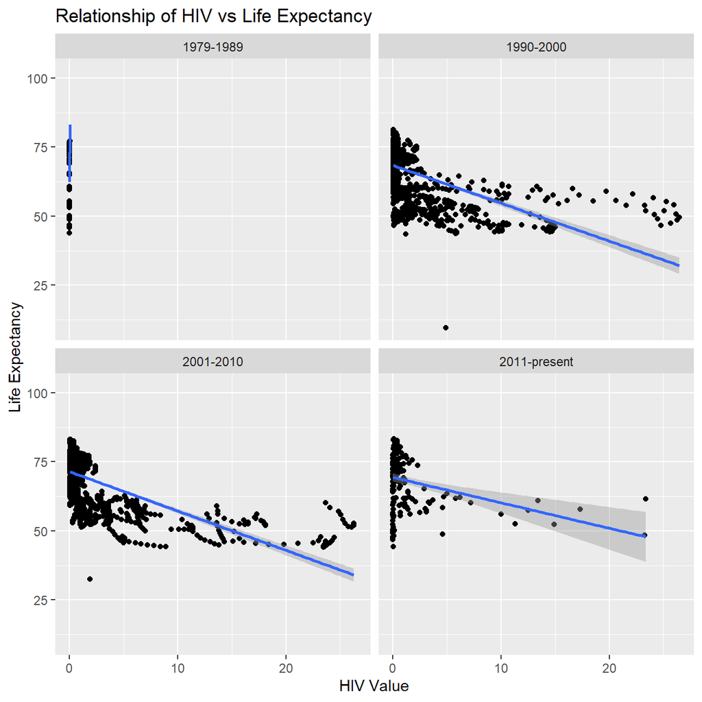

```r
hiv_life_expectancy_worldbank_data <- hiv_life_expectancy_worldbank_data %>%
  #create new variable 'interval', and assign values based on criteria below:
  mutate(interval = case_when(
    Year %in% c(1980:1989) ~ "1979-1989",
    Year %in% c(1990:2000) ~ "1990-2000",
    Year %in% c(2001:2010) ~ "2001-2010",
    #Year %in% c(1999:2009) ~ "1999-2009",
    TRUE ~ "2011-present"
  ))



ggplot(hiv_life_expectancy_worldbank_data, aes(x = HIV_Value , y = Life_Expectancy_Value)) +
  geom_point() +
  geom_smooth(method = "lm") +
   labs(
    title = "Relationship of HIV vs Life Expectancy",
    x = "HIV Value",
    y = "Life Expectancy"
  )+
  facet_wrap(~interval)+
  NULL
```

- We have faceted the graphs by intervals. We see that as the HIV Value increases the life expectancy decreases.
2. Now we analysed the relationship between fertility rate and GDP per capita? We generate a scatterplot with a smoothing line to report our results, using facetting as a useful tool.

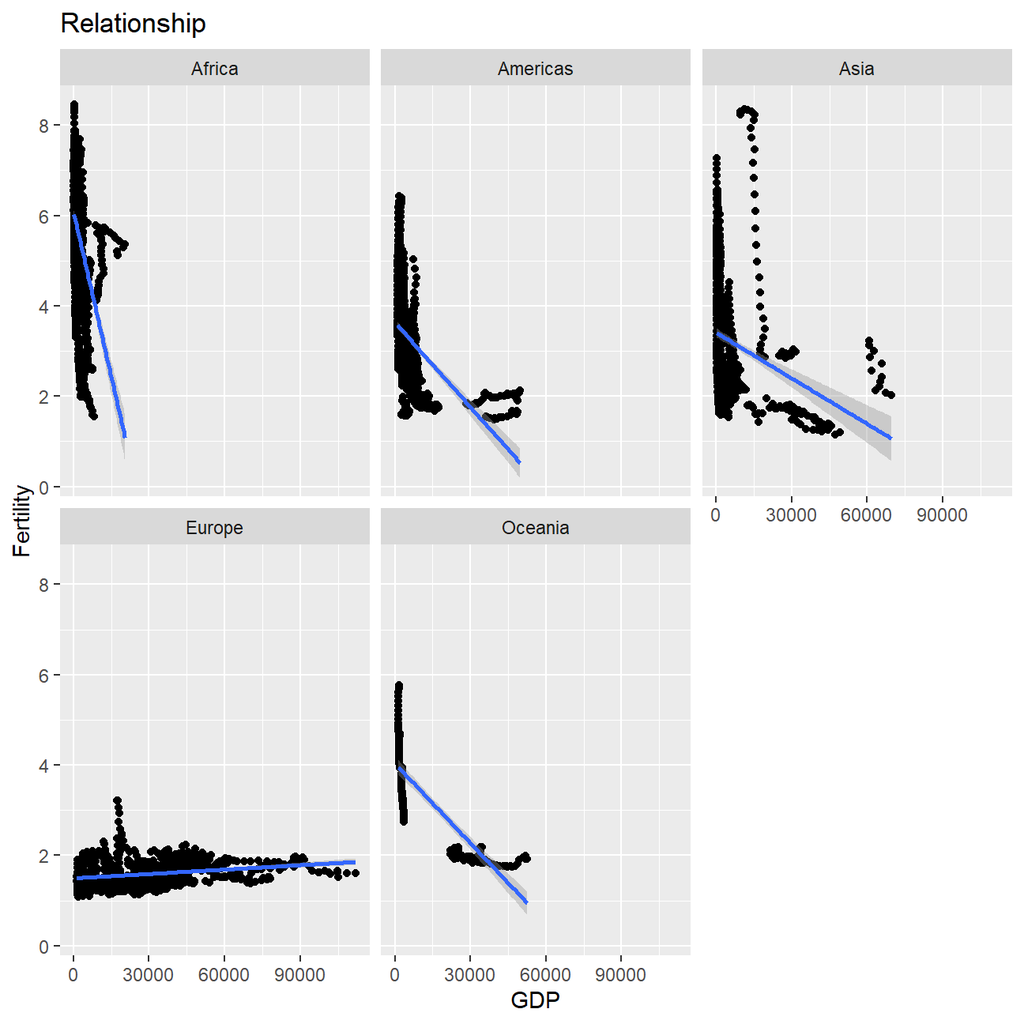

```r
library(countrycode)

#Creating a dataset hiv_life_expectancy_worldbank_data_continent which has a column for continents corresponding to each country

hiv_life_expectancy_worldbank_data_continent <- hiv_life_expectancy_worldbank_data

hiv_life_expectancy_worldbank_data_continent <- cbind(hiv_life_expectancy_worldbank_data, new_col = "continent")


hiv_life_expectancy_worldbank_data_continent$continent <- countrycode(sourcevar = hiv_life_expectancy_worldbank_data_continent$country,
                            origin = "country.name",
                            destination = "continent")


ggplot(hiv_life_expectancy_worldbank_data_continent, aes(x = NY.GDP.PCAP.KD , y = SP.DYN.TFRT.IN)) +
  geom_point() +
  geom_smooth(method = "lm") +
   labs(
    title = "Relationship",
    x = "GDP",
    y = "Fertility"
  )+
  facet_wrap(~continent)+

  NULL
```

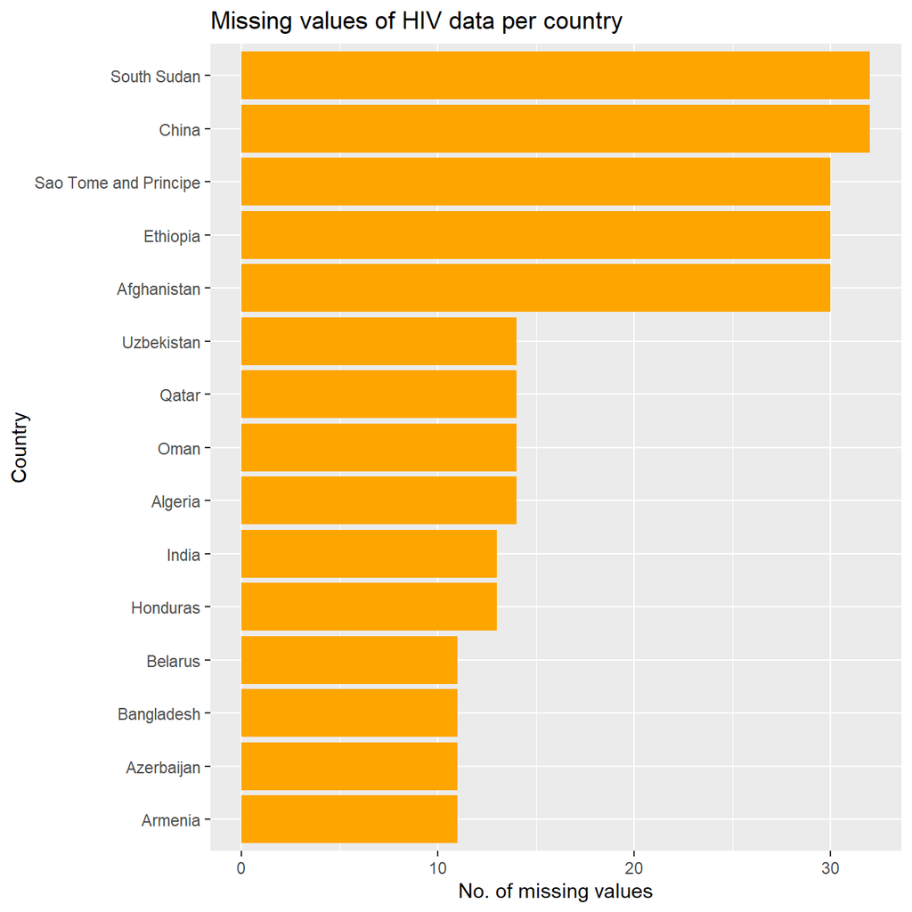

```r
#aggregate(x = HIV_Value, data=hiv_life_expectancy_worldbank_data, count(is.na(x)))


hiv_missing <- hiv_life_expectancy_worldbank_data %>%
  mutate(na_yes_no = ifelse( is.na(HIV_Value) , "Yes" , "No" )  ) %>%
  group_by(country,na_yes_no) %>%
  summarise(count_missing=n()) %>%
  filter( na_yes_no == "Yes" ) %>%
  arrange(-count_missing)


hiv_missing[1:15,] %>%
#  slice_max ( order_by = count_missing, n=5 ) %>%
  ggplot(aes(x = count_missing, y = fct_reorder(country, count_missing))) +
  geom_col(fill="orange")+
  labs(x="No. of missing values" , y="Country" , title= "Missing values of HIV data per country")+
    NULL
```

4. Now we see how the mortality rate for under 5 has changed by region.

```r
#now we filter the data from year 2011 and 1979
mortality_1979_2011 <- hiv_life_expectancy_worldbank_data_continent %>%
                      filter ( as.numeric(Year) %in% c(  1979,2011 ) )

#now we select the columns to consider
mortality_1979_2011 <- select( mortality_1979_2011 , c( "Year", "continent" , "country" , "SH.DYN.MORT" ))

#we rename the columns to add a character
mortality_1979_2011$Year = paste("y",mortality_1979_2011$Year,sep="")

#now we make the table wider to allow us to select the difference in values later
mortality_1979_2011_wide <- pivot_wider( data=mortality_1979_2011 , names_from = Year, values_from = SH.DYN.MORT  )


#now we add an additional column to calcualte the difference in mortality values
mortality_1979_2011_wide <- mortality_1979_2011_wide %>% mutate(mortality_diff = y2011 - y1979 )

#we group by the region and rank the mortality differences
mortality_1979_2011_ranked <- mortality_1979_2011_wide %>%
                          group_by(continent) %>%
                          summarise( country=country,  asc_ranking = rank(mortality_diff) , dsc_ranking = rank(-mortality_diff)  )


#as per our analysis the lesser mortality range difference means the worst improvement and the largest mortality rate differnce in 1979 and 2011 shows the best improved country

mortality_best5 <- mortality_1979_2011_ranked %>% filter( asc_ranking <=5  )

mortality_worst5 <- mortality_1979_2011_ranked %>% filter( dsc_ranking <=5  )


mortality_worst5 <-select( mortality_worst5  , c ( "continent" , "country"))

mortality_worst5
```

```
## # A tibble: 24 x 2
## # Groups:   continent [5]
##    continent country
##    <chr>     <chr>
##  1 Africa    Botswana
##  2 Africa    Central African Republic
##  3 Africa    Lesotho
##  4 Africa    Mauritius
##  5 Africa    Zimbabwe
##  6 Americas  Barbados
##  7 Americas  Canada
##  8 Americas  Costa Rica
##  9 Americas  Cuba
## 10 Americas  United States
## # ... with 14 more rows
```

```r
mortality_best5 <-select( mortality_worst5  , c ( "continent" , "country"))

mortality_best5
```

```
## # A tibble: 24 x 2
## # Groups:   continent [5]
##    continent country
##    <chr>     <chr>
##  1 Africa    Botswana
##  2 Africa    Central African Republic
##  3 Africa    Lesotho
##  4 Africa    Mauritius
##  5 Africa    Zimbabwe
##  6 Americas  Barbados
##  7 Americas  Canada
##  8 Americas  Costa Rica
##  9 Americas  Cuba
## 10 Americas  United States
## # ... with 14 more rows
```

5. We now check the relationship between primary school enrollment and fertility rate

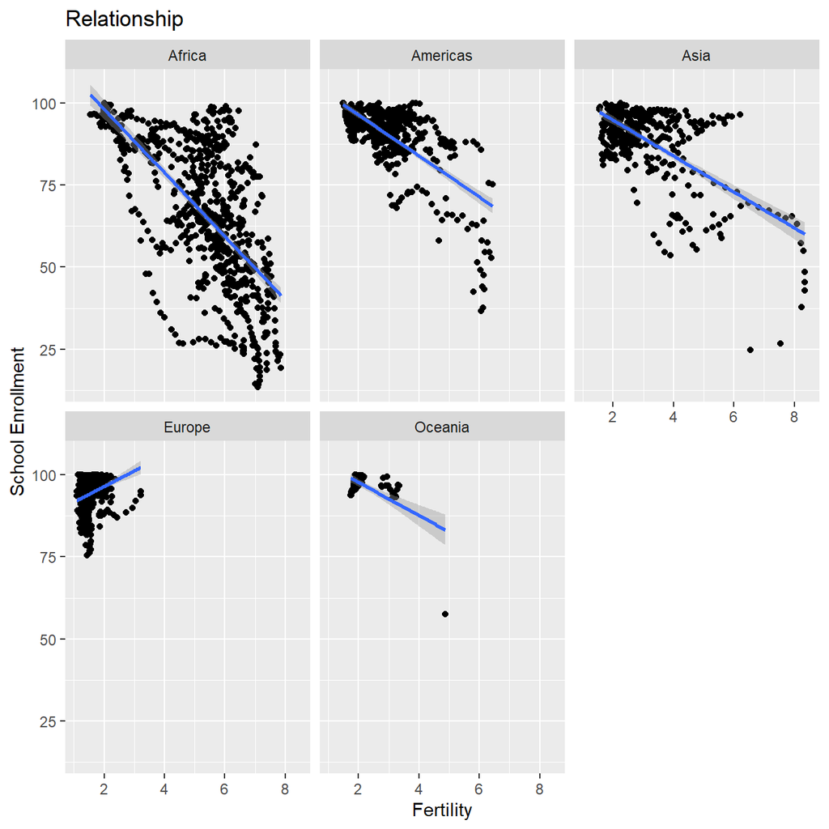

```r
ggplot(hiv_life_expectancy_worldbank_data_continent, aes(x = SP.DYN.TFRT.IN , y = SE.PRM.NENR)) +
  geom_point() +
  geom_smooth(method = "lm") +
   labs(
    title = "Relationship",
    x = "Fertility",
    y = "School Enrollment"
  )+
  facet_wrap(~continent)+
  NULL
```

Once again we see that Europe and the rest of the continents have different trends. - In Asia, Afirca, Americas and Oceania - the higher the fertility, the lesser is the school enrollment. - In Europe, the higher the fertility rate the more is the school enrollment.

# 5 Excess rentals in TfL bike sharing

Recall the TfL data on how many bikes were hired every single day. We can get the latest data by running the following

```r
url <- "https://data.london.gov.uk/download/number-bicycle-hires/ac29363e-e0cb-47cc-a97a-e216d900a6b0/tfl-daily-cycle-hires.xlsx"

# Download TFL data to temporary file
httr::GET(url, write_disk(bike.temp <- tempfile(fileext = ".xlsx")))
```

```
## Response [https://airdrive-secure.s3-eu-west-1.amazonaws.com/london/dataset/number-bicycle-hires/2021-08-23T14%3A32%3A29/tfl-daily-cycle-hires.xlsx?X-Amz-Algorithm=AWS4-HMAC-SHA256&X-Amz-Credential=AKIAJJDIMAIVZJDICKHA%2F20210911%2Feu-west-1%2Fs3%2Faws4_request&X-Amz-Date=20210911T192702Z&X-Amz-E…
##   Date: 2021-09-11 19:27
##   Status: 200
##   Content-Type: application/vnd.openxmlformats-officedocument.spreadsheetml.sheet
##   Size: 173 kB
## <ON DISK>  C:\Users\Raina\AppData\Local\Temp\RtmpMHwKro\file3c2c1fb13b86.xlsx
```

```r
# Use read_excel to read it as dataframe
bike0 <- read_excel(bike.temp,
                   sheet = "Data",
                   range = cell_cols("A:B"))

# change dates to get year, month, and week
bike <- bike0 %>%
  clean_names() %>%
  rename (bikes_hired = number_of_bicycle_hires) %>%
  mutate (year = year(day),
          month = lubridate::month(day, label = F),
          week = isoweek(day))
```

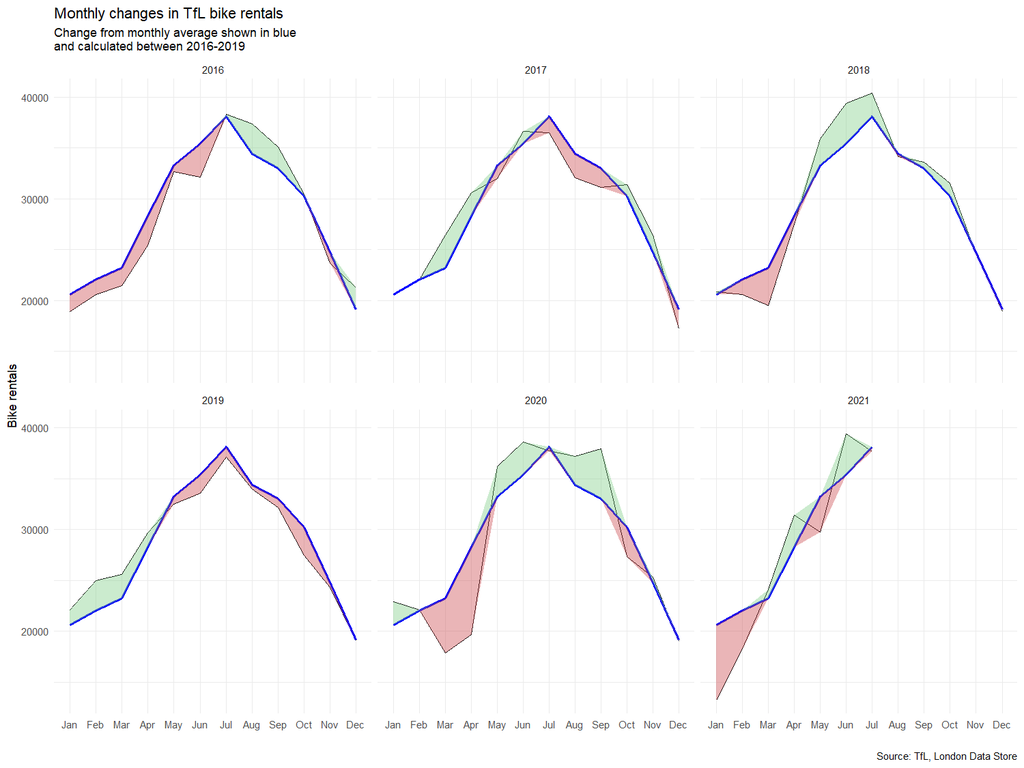

[figure not shown]

```r
# Calculates the average monthly bikes rented using data from 2016 to 2021.
expected_hires <- bike %>%
  filter(day>="2016-01-01")%>%
  group_by(year, month) %>%
  summarize(bikes_hired = mean(bikes_hired)) %>%  #takes the daily data and creates a monthly mean for each year/month combo
  group_by(month) %>%
  summarise(expected_hired = mean(bikes_hired)) #outputs mean bike rentals by month (Jan-Dec) with only 12 rows

#modifying the dataset and adding the averages previously calculated in expected_hires
plot_bike <- bike %>%
  filter(day>="2016-01-01")%>%
  group_by(year, month) %>%
  summarize(bikes_hired = mean(bikes_hired)) %>%  #gets the average bikes for each year/month combo 1/2016, 2/2016 ....
  inner_join(expected_hires, by = "month") %>% #adds column with the average bike rentals to each year/month combo
  mutate(fill = bikes_hired>expected_hired, #creates a True/Flase column if bikes rentals are above or below the average
         up = ifelse(bikes_hired>expected_hired, bikes_hired-expected_hired, 0), #calculates if above the average and the number of rentals above, if it is not 0 is given.
         down = ifelse(bikes_hired>expected_hired, 0,bikes_hired-expected_hired), #calculates if below the average and the number of rentals below, if it is not 0 is given.
         Month = month(month, label=T)) #gets the month value in chr format



plot_bike$lower = apply(plot_bike[,3:4],1,min) # creates a column taking the smallest value from actual vs average bikes hired
plot_bike$higher = apply(plot_bike[,3:4],1,max) # creates a column taking the largest value from actual vs average bikes hired
plot_bike$date = ym(paste(plot_bike$year,plot_bike$month)) #creates column with date in ym format

#Recreating the plot
plot_bike %>%
  ggplot(aes(x=Month)) +
  geom_line(aes( y=expected_hired, group=year),colour="blue",size=2)+ #draws the average
  geom_line(aes(y=bikes_hired, group=year),colour="black",size=.5)+ #draws the actual bikes hired
  geom_ribbon(aes(ymin=expected_hired,ymax=expected_hired+up, group=year),fill="#7DCD85",alpha=0.4)  + #creates green shaded
  geom_ribbon(aes(ymin=expected_hired,ymax=expected_hired+down, group=year),fill="#CB454A",alpha=0.4)+ #creates red shaded
  facet_wrap(~year)+ #creates plots for years
  theme(axis.text.x = element_text(angle=60 , hjust=1) ) +
 # theme_bw() +
  labs(title = "Monthly changes in TfL bike rentals",
                    subtitle = "change from monthly average shown in blue and calculated between 2016-2019", caption= "Source: TfL, London Data Store",
       x="", y="Bike Rentals") +
  NULL
```

The second graph we recreated looks at percentage change from the expected level of weekly rentals. The two grey shaded rectangles correspond to Q2 (weeks 14-26) and Q4 (weeks 40-52).

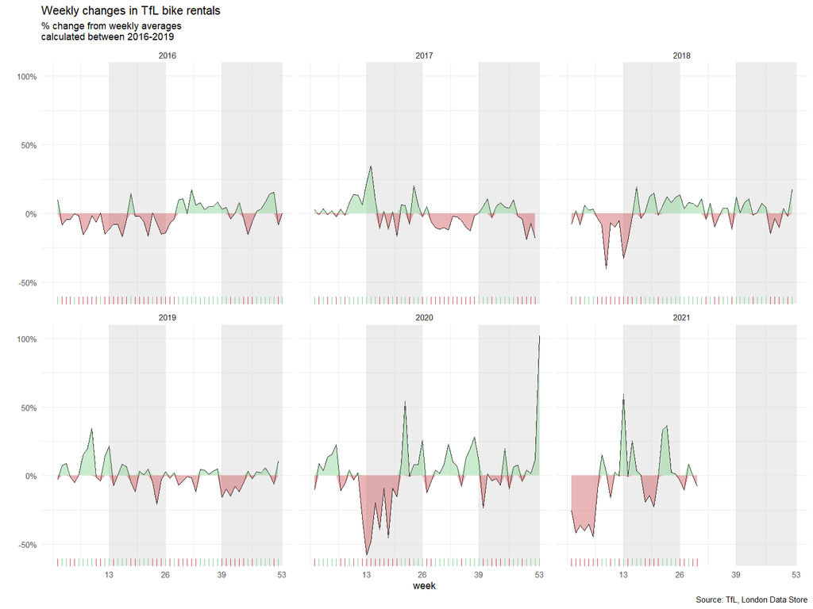

Here the green shaded region shows the percentage of rentals above the average and the red shows the percentage below.

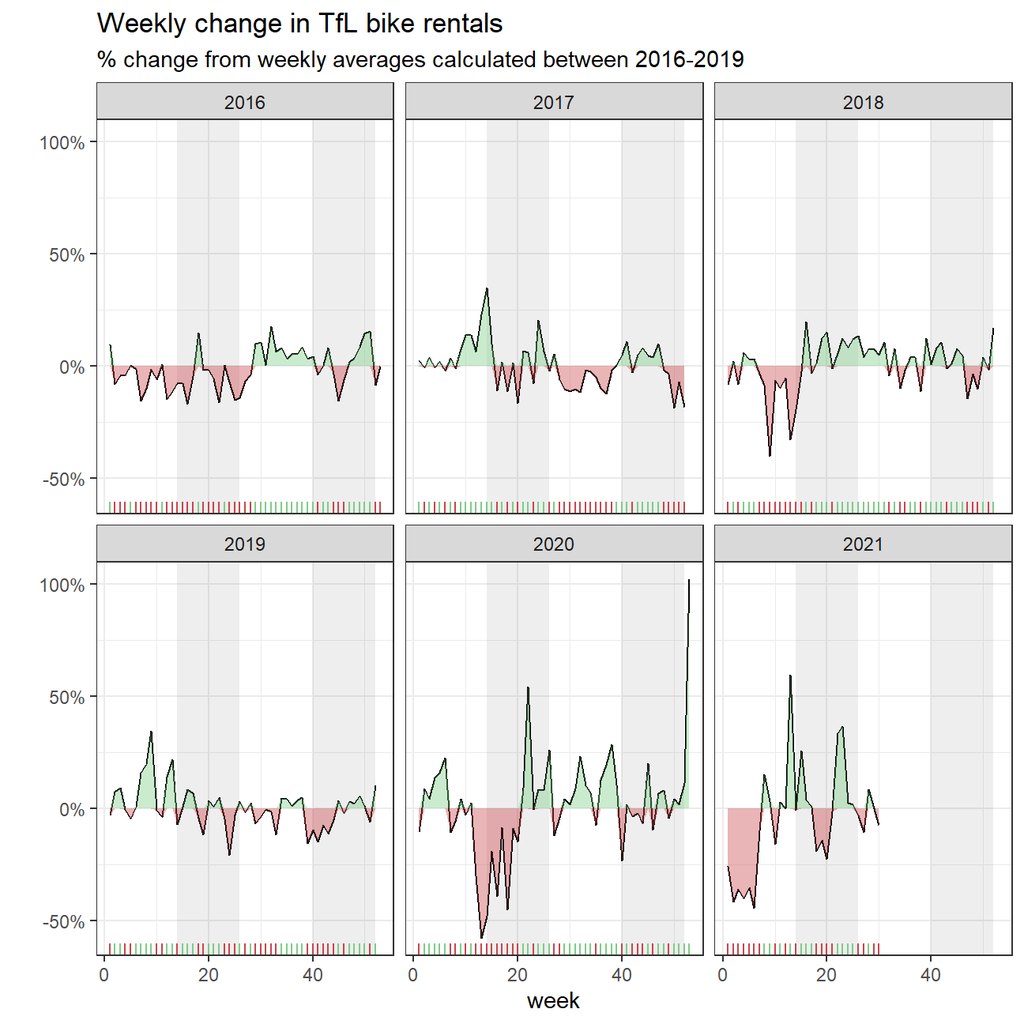

```r
#Calculating the weekly means
expected_hires_week <- bike %>%
  filter(day>="2016-01-01" & day<"2020-01-01")%>%
  group_by(year, week) %>%
  summarize(bikes_hired = mean(bikes_hired)) %>%  #takes the daily data and creates a weekly mean for each year/week combo
  group_by(week) %>%
  summarise(expected_hired = mean(bikes_hired)) #outputs mean bike rentals by week with 53 rows


#modifying the dataset and adding the averages previously calculated in expected_hires
plot_bike_week <- bike %>%
  filter(day>="2016-01-01")%>%
  filter(!(year==2021 & week==53)) %>% # gets rid of week 53 in 2021 causing weird line in plot.
  group_by(year, week) %>%
  summarize(bikes_hired = mean(bikes_hired)) %>%
  inner_join(expected_hires_week, by = "week") %>% #joins the two datasets (one with mean) by week
  mutate(fillcolor = bikes_hired>expected_hired,
         excess_rentals = bikes_hired - expected_hired, #calculates rentals above average
         percentage_change_expected = (excess_rentals/expected_hired), #calcualtes percentage above avg
         up = ifelse(percentage_change_expected>0, (excess_rentals/expected_hired), 0),
         down = ifelse(percentage_change_expected>0, 0,(excess_rentals/expected_hired)))

plot_bike_week$lower = apply(plot_bike_week[,3:4],1,min) # creates a column taking the smallest value from actual vs average bikes hired
plot_bike_week$higher = apply(plot_bike_week[,3:4],1,max) # creates a column taking the largest value from actual vs average bikes hired


plot_bike_week %>% ggplot(aes(x=week, y=percentage_change_expected)) +
  annotate(geom="rect", xmin = 14,xmax = 26, ymin=-Inf, ymax=Inf, alpha=0.1) + #Q2
  annotate(geom="rect", xmin = 40,xmax = 52, ymin=-Inf, ymax=Inf, alpha=0.1) + #Q4
  geom_line(aes(x=week, y=percentage_change_expected)) +  #Creates average line
  geom_ribbon(aes(ymin=0,ymax=up, group=year),fill="#7DCD85",alpha=0.4)  + #adds green shaded
  geom_ribbon(aes(ymin=0,ymax=down, group=year),fill="#CB454A",alpha=0.4)+ #adds red shaded
  geom_rug(aes(x=week), color=ifelse(plot_bike_week$fillcolor,"#7DCD85","#CB454A"), sides="b") +
  facet_wrap(~year) +
  scale_y_continuous(labels = scales::percent) + #adds percent on axis
  theme_bw() +
  theme(legend.position = "none") +
  labs(title = "Weekly change in TfL bike rentals",
                    subtitle = "% change from weekly averages calculated between 2016-2019",
       y="")
```

# 6 Details

Team Members: Alex Kubbinga, Clara Moreno Sanchez, Jean Huang, Raghav Mehta, Raina Doshi, Yuan Gao